# Paper figures

Three groups in the tab bar: In the Paper, Candidates, and Not in the Paper (figures set aside, and the superseded views of the 96-run grid, kept for review). Each tab also says which it is.

## Intervention effects

**In the paper.** Figure 7 of the paper since 2026-11-27 (Results, opening), on a landscape page: Intervention Effects per Unit Substituted in the North, by Region. The twelve no-rule runs, fill = North, South and World, every response divided by V, the primary demand the intervention shifts (substitution_volume.csv); a Value added row. World = the change of the world total in % of its baseline (value added reproduces vaW of runs180.csv); deficit, current account and trade balance in % of world value added; wage share weighted by baseline value added. Replaced the North and South figures with all four rules (Figures 7 and 8 until 2026-11-27, now under Not in the Paper). Shown here at site size; the paper's copy is drawn at print size (effects_by_region_48_paper). Source: R/figures/plot_candidates_48.R.

48 runs: the North intervenes (sc1-sc12, a 20% substitution from t = 70), North/South, OPENFIX-fiat with the North's bills as the reserve, under no rule and three fiscal rules. Responses are means over t = 79-100 against each run's own baseline (analysis tag 20261121_ce79).

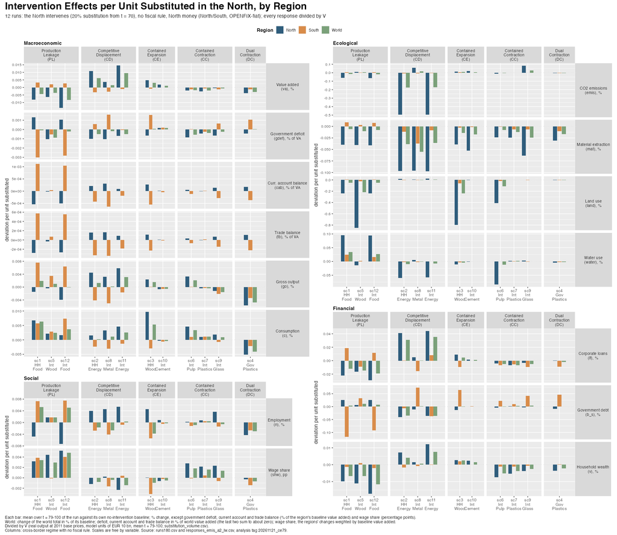

## Pair intensities

**In the paper.** The paper's fig-pair-intensities, Figure 6 (Ecological block), redrawn 2026-11-25 as a 2 x 2 scatter: each pair's substitute against its primary sector, total intensity m = L'u, log scales, dashed x = y; colour = material pair (the scale shared with South content and the PCA). Land and water are now EXIOBASE land use (km2) and blue water (Mm3) per unit of output, replacing the untraced workbook vectors (R/scenarios/correct_land_water.R). North/South fiat baseline at t = 70 (`revised_ns_capital_highfinance_openfix_fiat_credit`, the baseline of the 48 runs), re-sourced from EU/RoW in the manuscript on 2026-11-23, with its caption and the Section 4.2 text.

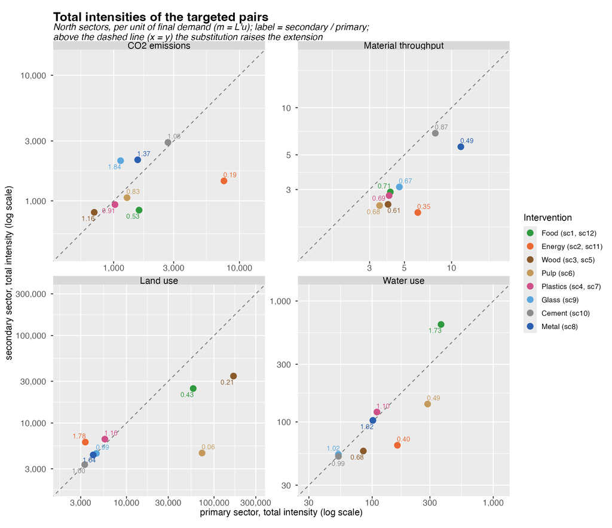

## Channel volumes (paper)

**In the paper.** The paper's fig-demand-structure, Figure 3 (Model, MRIO accounting, since 2026-11-26), redrawn 2026-11-26: only what the North buys, from the North and from the South (2 x 2), legend at the right. North/South fiat baseline at t = 70 (`revised_ns_capital_highfinance_openfix_fiat_credit`, the baseline of the 48 runs), re-sourced from EU/RoW in the manuscript on 2026-11-23, with its caption and the Section 4.2 text.

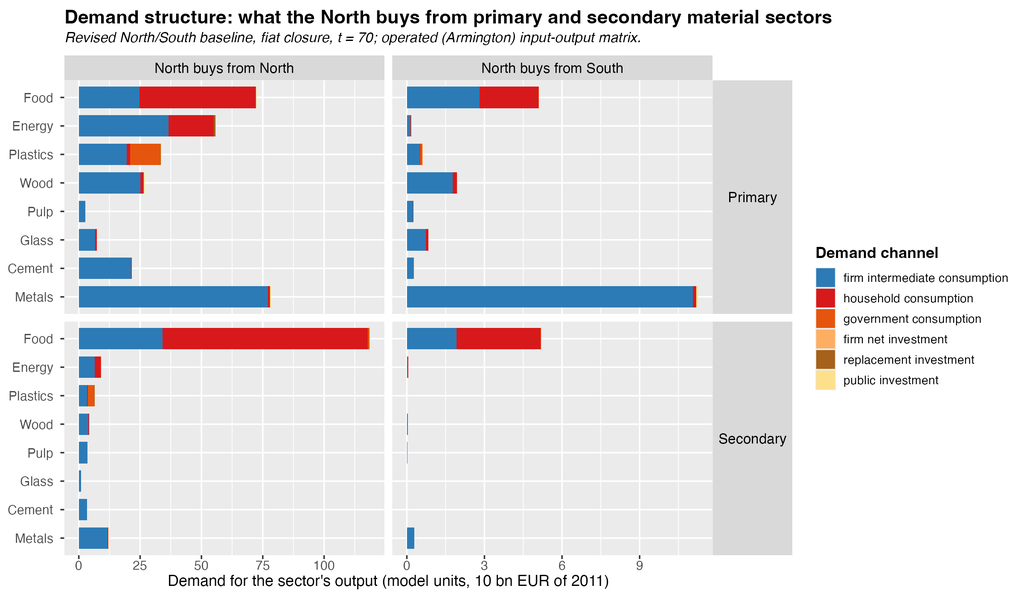

## Imports (paper)

**In the paper.** The paper's fig-import-decomp, Figure 4 (Model, MRIO accounting, since 2026-11-26). North/South fiat baseline at t = 70 (`revised_ns_capital_highfinance_openfix_fiat_credit`, the baseline of the 48 runs), re-sourced from EU/RoW in the manuscript on 2026-11-23, with its caption and the Section 4.2 text.

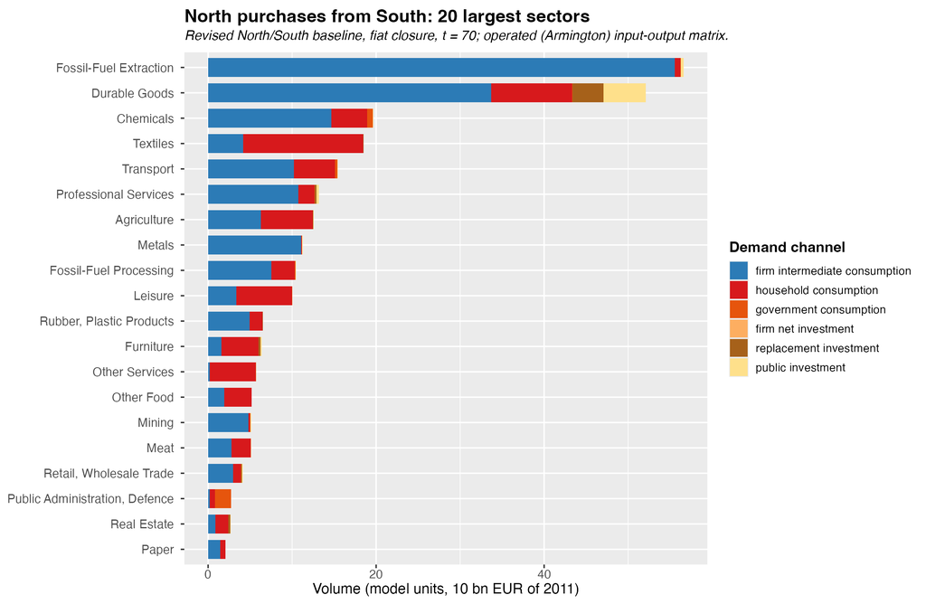

## Upstream (paper)

**In the paper.** The paper's fig-leontief, Figure 5 (Model, MRIO accounting, since 2026-11-26): upstream requirements of the North's primary material sectors. North/South fiat baseline at t = 70 (`revised_ns_capital_highfinance_openfix_fiat_credit`, the baseline of the 48 runs), re-sourced from EU/RoW in the manuscript on 2026-11-23, with its caption and the Section 4.2 text.

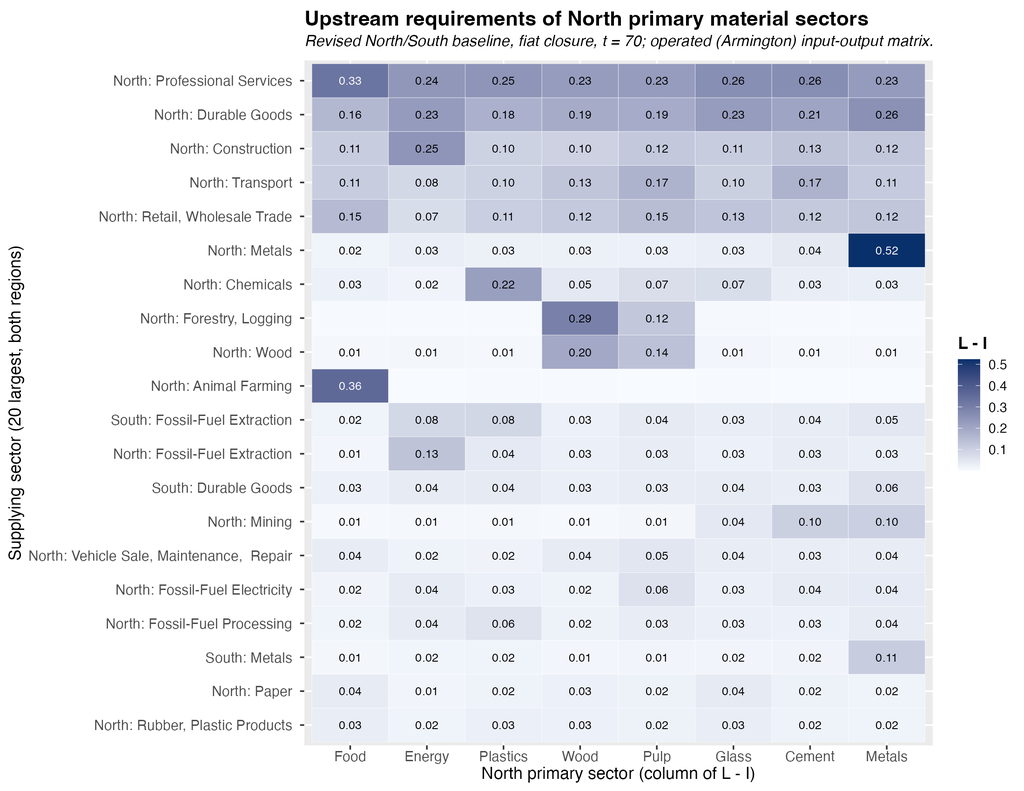

## Embodied balance

**Not in the paper: superseded, proposed for removal.** fig-embodied-48, removed from the paper on 2026-11-25 (the numbers stay in the text of Section 4.1): change in the North's net embodied imports from the South, % of the baseline net flow, by intervention and fiscal rule. Land and water on EXIOBASE intensities.

48 runs: the North intervenes (sc1-sc12, a 20% substitution from t = 70), North/South, OPENFIX-fiat with the North's bills as the reserve, under no rule and three fiscal rules. Responses are means over t = 79-100 against each run's own baseline (analysis tag 20261121_ce79).

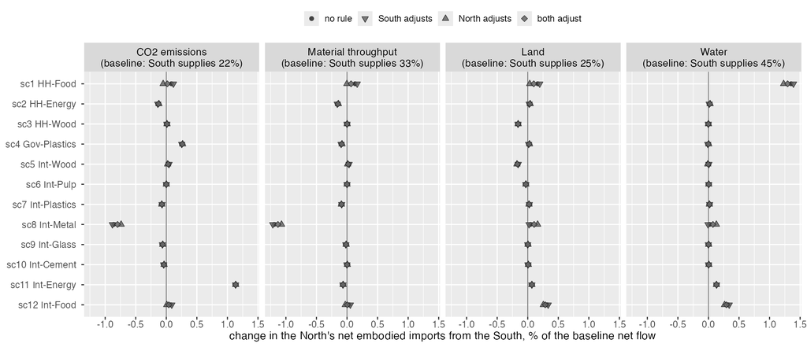

## Families, unannotated

**Not in the paper: superseded, proposed for removal.** The paper's fig-ward-families until 2026-11-25, replaced there by the annotated version (Families): Ward hierarchy of the 48 runs; tiles give the cross-border regime.

48 runs: the North intervenes (sc1-sc12, a 20% substitution from t = 70), North/South, OPENFIX-fiat with the North's bills as the reserve, under no rule and three fiscal rules. Responses are means over t = 79-100 against each run's own baseline (analysis tag 20261121_ce79).

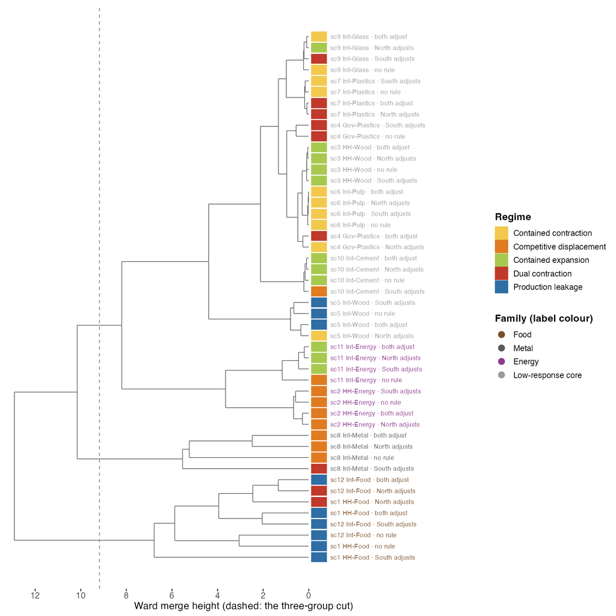

## South content

**In the paper.** Figure 11 of the paper since 2026-11-28 (Results, Why food and wood leak and metal and energy displace), redrawn 2026-11-25: left, South output per unit of North final demand, secondary against primary, dashed x = y; right, its change against the North current account per unit substituted. Colour = material pair.

48 runs: the North intervenes (sc1-sc12, a 20% substitution from t = 70), North/South, OPENFIX-fiat with the North's bills as the reserve, under no rule and three fiscal rules. Responses are means over t = 79-100 against each run's own baseline (analysis tag 20261121_ce79).

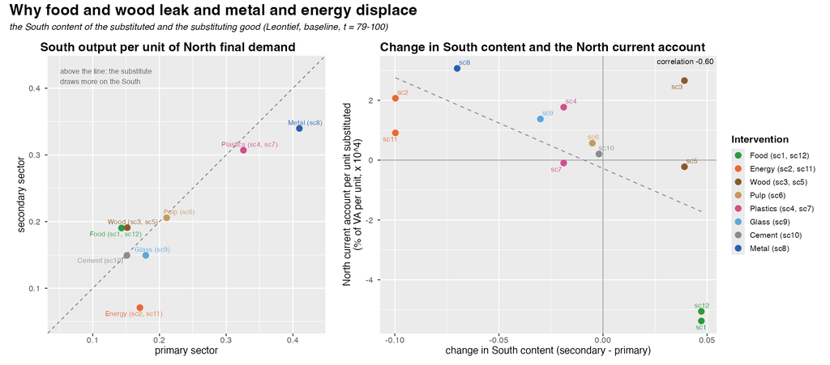

## Response profile

**In the paper.** Figure 9 of the paper since 2026-11-28 (Results, Size, leverage and the intervention families; Figure 13 from 2026-11-27): Response Profile, how each intervention moves the two economies, the redrawn version (author). Size panel restored 2026-11-28 (author): the no-rule size with V in brackets, so Leverage = Size / V reads across the two panels. Leverage: the no-rule bar coloured by regime, the three fiscal rules as points, ordered by leverage (stacking the rules fails: deficit ≤ both ≤ surplus holds in 2 of 12). Dimension: Figure 13's earlier block shares, each tile coloured by whether the block improves or worsens (ecological pressures down; activity, employment, incomes and the wage share up; wealth and capital up, private and public debt down; External from the North's view). The paper's copy is drawn without title or notes (response_profile_rules_48_paper). Source: R/figures/plot_candidates_48.R.

48 runs: the North intervenes (sc1-sc12, a 20% substitution from t = 70), North/South, OPENFIX-fiat with the North's bills as the reserve, under no rule and three fiscal rules. Responses are means over t = 79-100 against each run's own baseline (analysis tag 20261121_ce79).

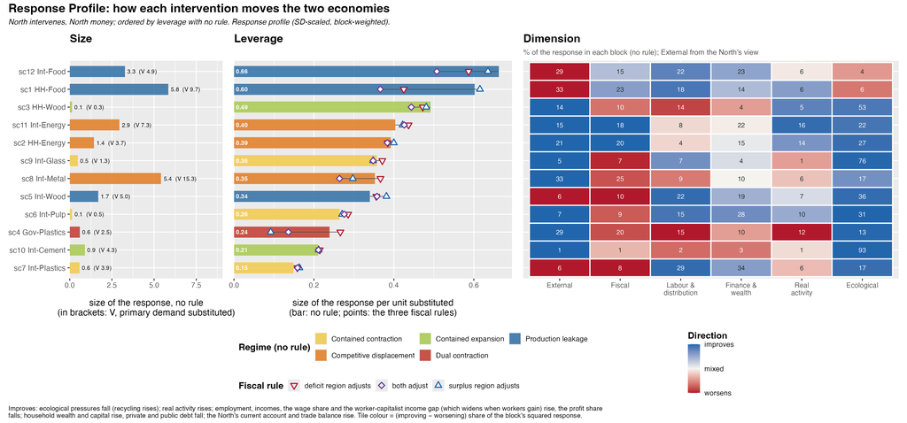

## Effects by regime group

**Not in the paper.** Moved from Candidates to Not in the Paper 2026-11-28 (author). Intervention Effects split by regime group (2026-11-27), because the PL and CD responses are an order of magnitude larger than the CE, CC and DC ones and flatten them on a shared axis. Two figures, North and South side by side in each: columns = regime, then region (nested strips); rows = variables; scales free by row, shared across regimes and regions within a figure, not across the two. Source: R/figures/plot_candidates_48.R.

48 runs: the North intervenes (sc1-sc12, a 20% substitution from t = 70), North/South, OPENFIX-fiat with the North's bills as the reserve, under no rule and three fiscal rules. Responses are means over t = 79-100 against each run's own baseline (analysis tag 20261121_ce79).

### Production Leakage and Competitive Displacement

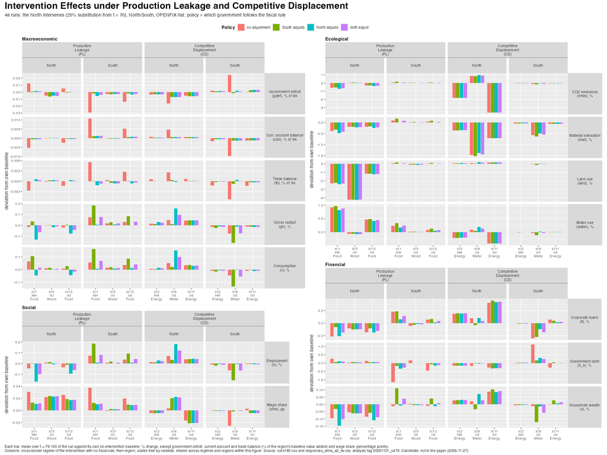

### Contained Expansion, Contained Contraction and Dual Contraction

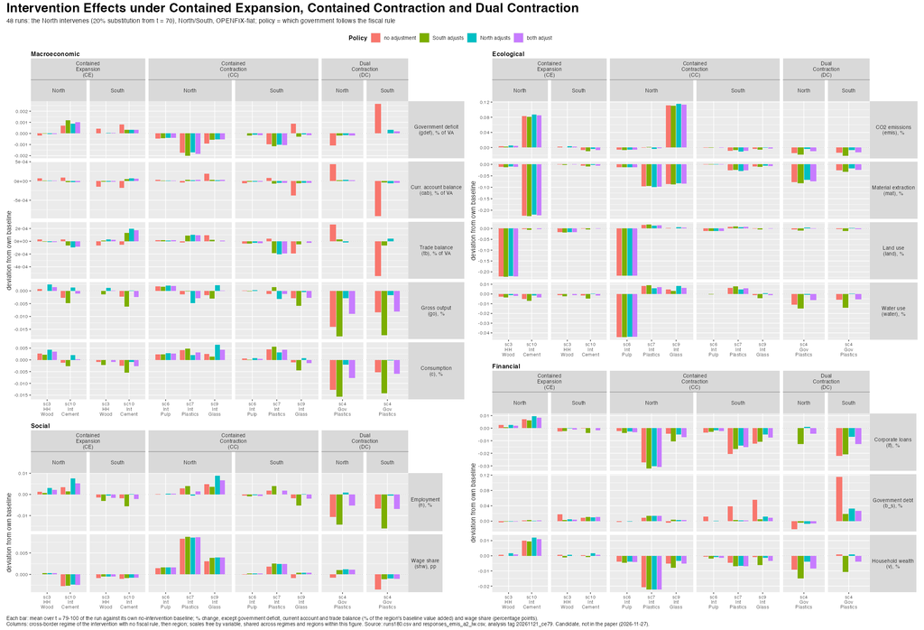

## Response profile, four panels

**Not in the paper.** Out of the paper 2026-11-27 (author), replaced by the redrawn Response Profile. Until then Figure 13 (14 before the Intervention Effects figures were merged): size, leverage, block shares (Axis) and the sign of the North current account, no rule; legends collected below, the regime legend in one row. Source: R/figures/plot_response_profile_south_content.R.

48 runs: the North intervenes (sc1-sc12, a 20% substitution from t = 70), North/South, OPENFIX-fiat with the North's bills as the reserve, under no rule and three fiscal rules. Responses are means over t = 79-100 against each run's own baseline (analysis tag 20261121_ce79).

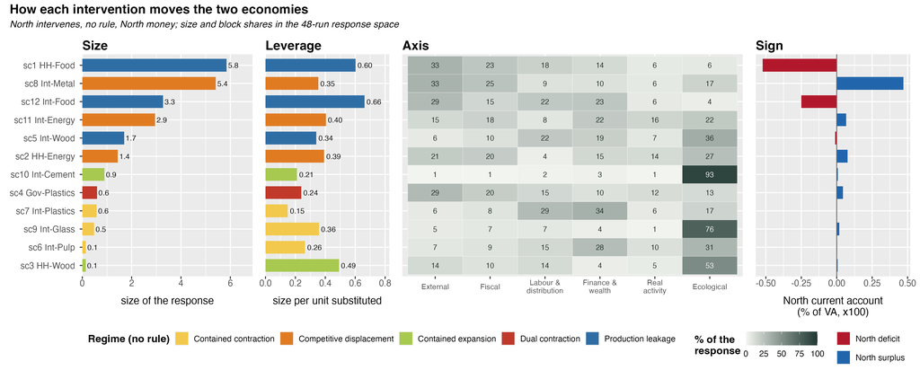

## Extraction vs CO2

**Not in the paper.** Moved from Candidates to Not in the Paper 2026-11-27 (author). Moved to Candidates 2026-11-26 and out of the manuscript the same day, replaced by the Emission grid (author). fig-extraction-co2 (Results, Two-sided ecology): world extraction against world CO2, 48 runs; South emissions corrected (D-77).

48 runs: the North intervenes (sc1-sc12, a 20% substitution from t = 70), North/South, OPENFIX-fiat with the North's bills as the reserve, under no rule and three fiscal rules. Responses are means over t = 79-100 against each run's own baseline (analysis tag 20261121_ce79).

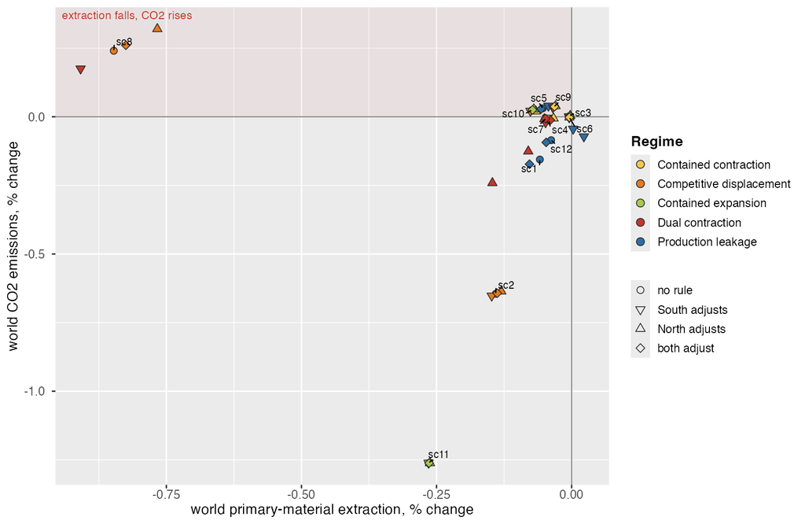

## Cross-border asymmetries

**In the paper.** Figure 14 of the paper since 2026-11-28 (Results, Two-sided ecology; Figure 12 after the regime counts from 2026-11-26): the submitted paper's Figure 4 in its layout, on the revised model. The 12 interventions with no fiscal rule, North money: North response (x) against South response (y) for employment, CO2, material extraction, and government debt, a panel of world material extraction against world CO2 emissions (replacing the current account, 2026-11-28, author; world CO2 from the corrected South intensities), plus dual inequality (North wage share, pp, against South government debt, %; upper left = dual regressivity). Colour = intervention (material hues, second of a pair darker); halo = cross-border regime; dotted = 45 degree line. Mean over t = 79..100 against the own baseline; South emissions corrected (D-77). Source: R/figures/plot_cross_border_48.R.

48 runs: the North intervenes (sc1-sc12, a 20% substitution from t = 70), North/South, OPENFIX-fiat with the North's bills as the reserve, under no rule and three fiscal rules. Responses are means over t = 79-100 against each run's own baseline (analysis tag 20261121_ce79).

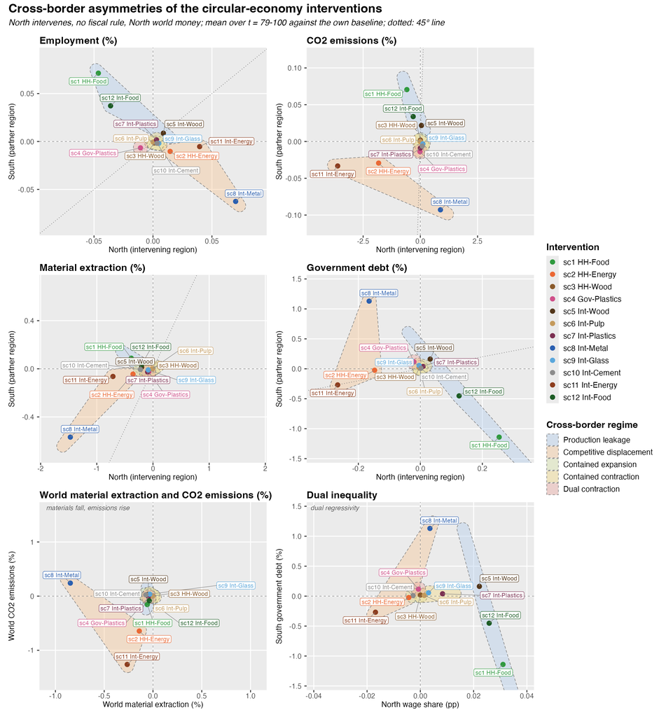

## Who adjusts

**In the paper.** Figure 13 of the paper since 2026-11-28 (Results, Who adjusts: surplus and deficit): effect of the fiscal rule on world value added against the current-account gap the intervention opens. Redrawn 2026-11-26: titled, coloured by intervention, shapes = policy as in the PCA, grey dashed segments join one intervention's three rule runs, labels at the both-adjust run, crosses = South money with no rule (world VA minus the North-money no-rule run); across the 12 interventions it tracks South adjusts, correlation 0.998. Earlier: grey dashed verticals = one intervention's three rule runs.

48 runs: the North intervenes (sc1-sc12, a 20% substitution from t = 70), North/South, OPENFIX-fiat with the North's bills as the reserve, under no rule and three fiscal rules. Responses are means over t = 79-100 against each run's own baseline (analysis tag 20261121_ce79).

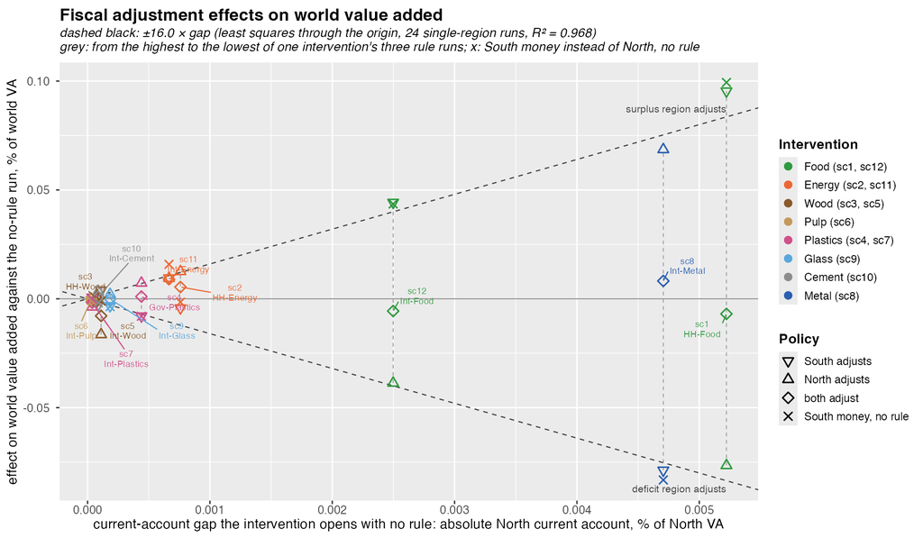

## Embodied networks

**In the paper.** Figure 1 of the paper (Introduction, the EUE paragraph) since 2026-11-26; arrows curved again and opacity capped at 0.85. EXIOBASE 3.8.2 ixi 2011, North/South concordance: the largest cross-border supplier-to-buyer links of embodied material (used extraction only), emissions, land and water. Proposed as Figure 1 (net North-South embodied flows). Redrawn 2026-11-25: the EU-27 of 2011 summed into one node (23 nodes); straight black arrows from the region where the impact occurs to the region whose final demand drives it, opacity and width proportional to the flow; each panel gives the share of the North's footprint occurring in the South, gross and net (material 41.2% / 30.6%, emissions 26.7% / 17.4%, land 32.1% / 19.1%, water 50.1% / 40.1%). Layout: Fruchterman-Reingold on each region's four largest partners (thin lines). On used extraction, South-to-North material flows are 3.89 times North-to-South; the model's own intensity counts used plus unused extraction, which the paper does not yet say. Source: tools/exiobase/exio_resource_network.py (--replot redraws from the saved flow tables).

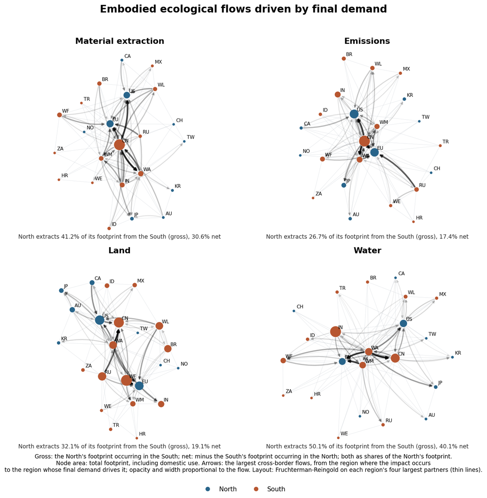

## Net positions

**In the paper.** Figure 2 of the paper (Introduction, after the network figure) since 2026-11-26: the six largest net receivers and net sources of each embodied flow, 2011, EU-27 as one region; net = impact embodied in a region's final demand occurring abroad minus impact on its territory embodied in foreign final demand, % of all cross-border flow. Source: R/figures/plot_embodied_net_positions.R.

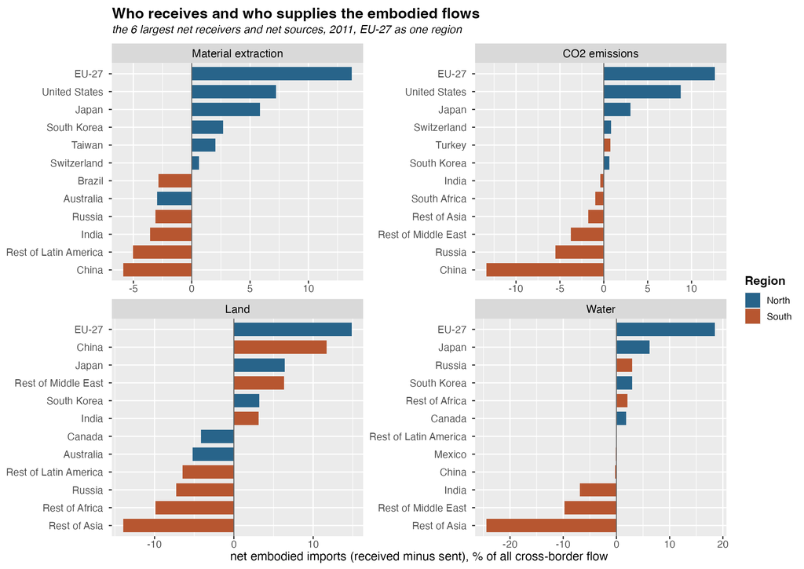

## Industry network

**Not in the paper.** Moved from Candidates to Not in the Paper 2026-11-27 (author). The national-industry network behind the embodied flows (--industry-only --max-edges 600), cross-border links only. Open: label overlap. Source: tools/exiobase/exio_resource_network.py.

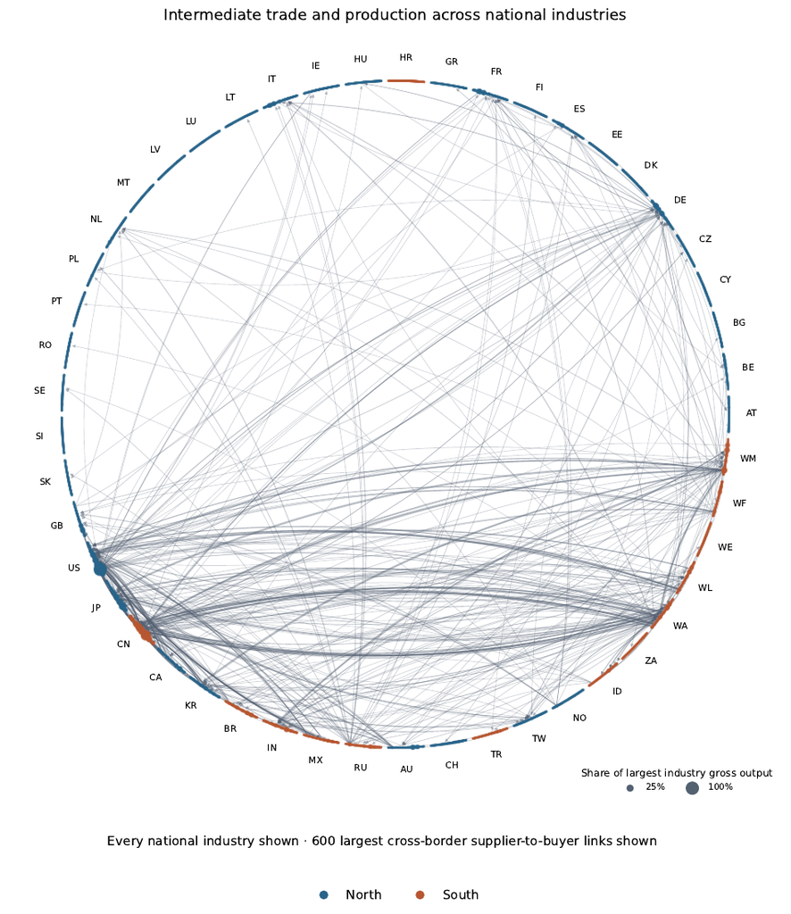

## Analysis of variance

**Candidate, not yet in the paper.** Under Candidates for now (author, 2026-11-28), though it is Figure 12 of the paper since 2026-11-28 (Results, Who adjusts: surplus and deficit), the 60-run version: the 48 runs and the twelve no-rule runs under South money in one decomposition. The South's money was run with no rule only, so the reserve-currency term is the contrast between the two no-rule runs of each intervention; each intervention has the same five runs, so the five terms (intervention, fiscal rule, reserve currency and the two interactions) are orthogonal and sum to the total. Rule and currency labelled by role: 4.5% and 1.7% (by region 0.2% and 0.1%, in the text). (a) each term split by the intervention that carries it, (b) by the outcome block it moves: the rule acts with the intervention on the fiscal and external blocks, the currency on distribution and finance, neither on the ecological block. Drawn at print width. Source: R/figures/plot_anova_pca_48.R (anova_60_shares.csv).

48 runs: the North intervenes (sc1-sc12, a 20% substitution from t = 70), North/South, OPENFIX-fiat with the North's bills as the reserve, under no rule and three fiscal rules. Responses are means over t = 79-100 against each run's own baseline (analysis tag 20261121_ce79).

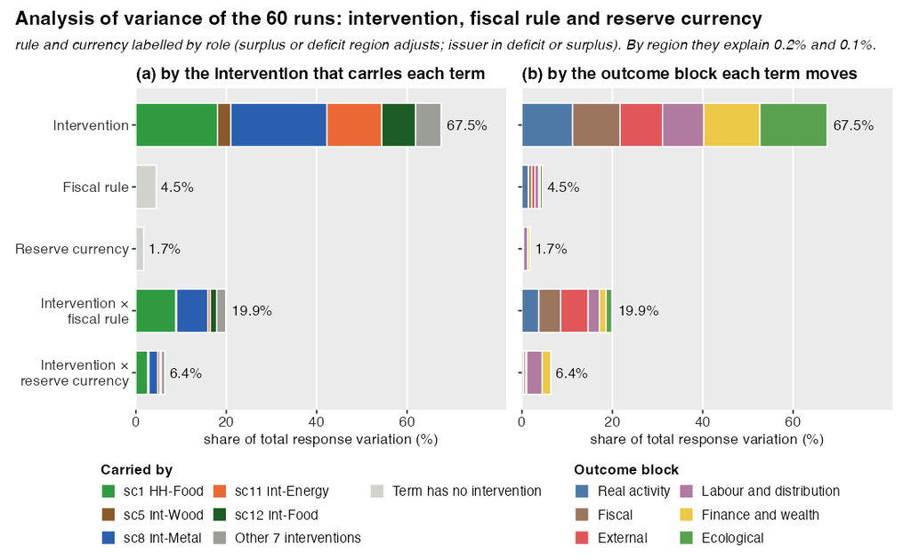

## ANOVA, block composition

**Candidate, not yet in the paper.** New 2026-11-28 (author): the 60-run ANOVA with panel (b) normalised within each term, so each bar runs from 0 to 100% and reads as the composition of that term's variation by outcome block (the share of the share); the term's share of the total variation is printed to the right of its bar. Panel (a) as in the paper's Figure 12. Read: the fiscal rule's own effect is 31% real activity; the reserve currency and its interaction with the intervention are 53% labour and distribution and 27-30% finance and wealth; the rule's interaction with the intervention is 31% external and 24% fiscal. Source: R/figures/plot_anova_pca_48.R (anova_60_shares.csv).

48 runs: the North intervenes (sc1-sc12, a 20% substitution from t = 70), North/South, OPENFIX-fiat with the North's bills as the reserve, under no rule and three fiscal rules. Responses are means over t = 79-100 against each run's own baseline (analysis tag 20261121_ce79).

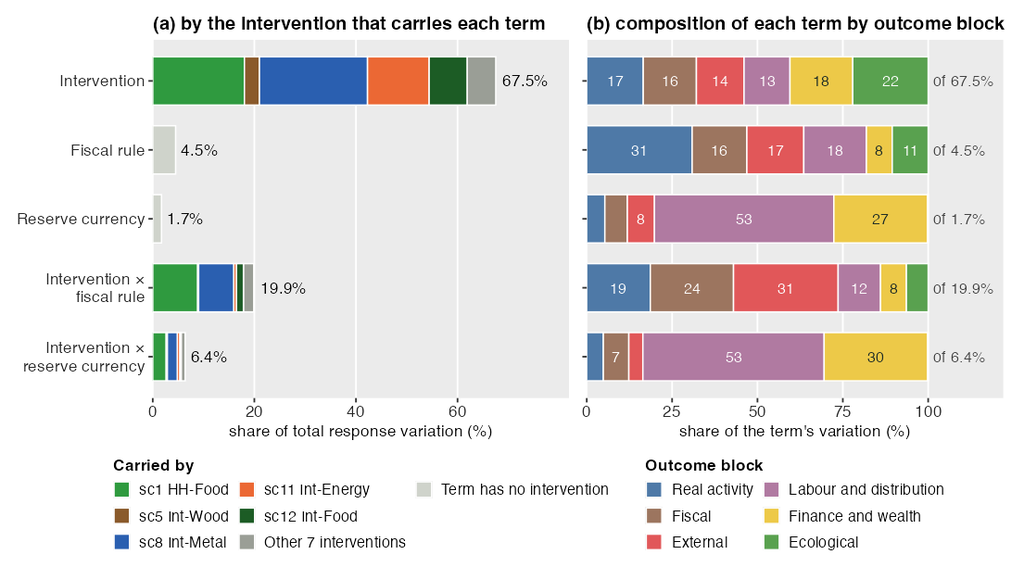

## ANOVA, 48 + 24 runs

**Candidate, not yet in the paper.** Under Candidates for now (author, 2026-11-28). Figure 12 of the paper on 2026-11-28 until replaced the same day by the 60-run version: left, the 48 runs, intervention x fiscal rule, by region and by role; right, the 24 no-rule runs, intervention x reserve currency; bottom, the role labelling split by outcome block. Source: R/figures/plot_anova_pca_48.R (anova_48_shares.csv, anova_24_money_shares.csv, anova_role_by_block.csv).

48 runs: the North intervenes (sc1-sc12, a 20% substitution from t = 70), North/South, OPENFIX-fiat with the North's bills as the reserve, under no rule and three fiscal rules. Responses are means over t = 79-100 against each run's own baseline (analysis tag 20261121_ce79).

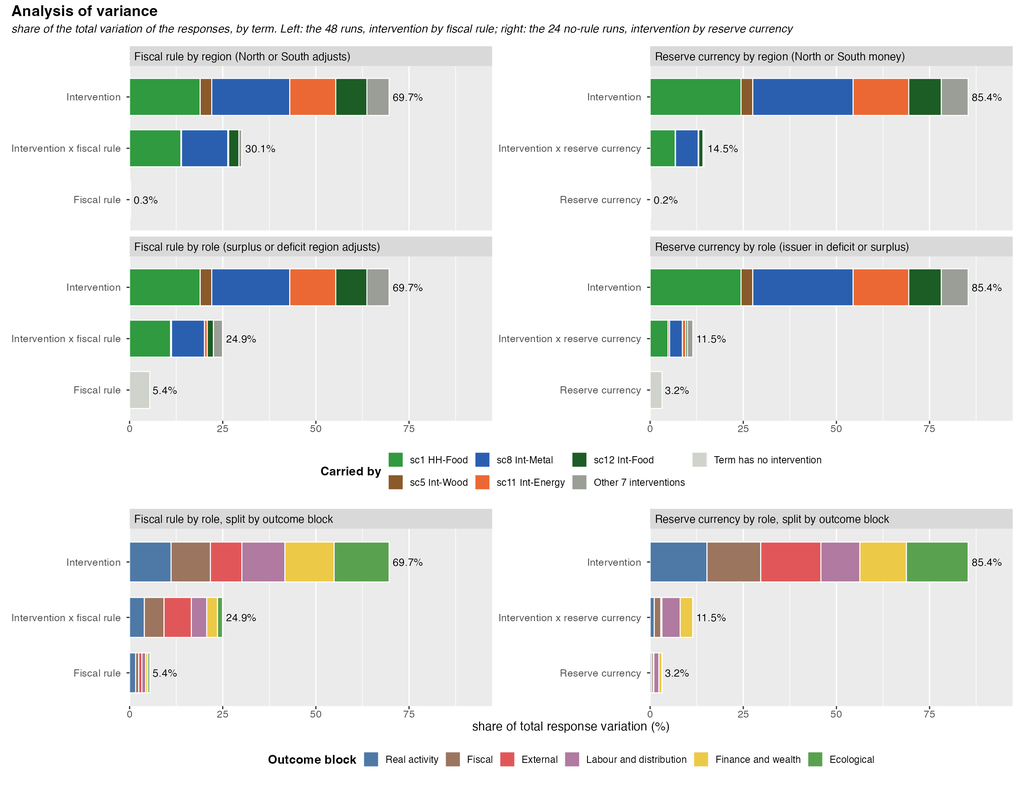

## Trilemma

**Candidate, not yet in the paper.** New 2026-11-28 (author), in the Results draft (qmd/reports/scenarios/2026-11-28-results-section-draft.qmd, Section 4.9), not yet in the paper: the trilemma of the 48 runs as two three-set Venn diagrams. Ecological: (a) world extraction falls, (b) world extraction and world CO2 both fall; macroeconomic: world value added does not fall; social: the worker share of disposable income does not fall in either region. Two runs pass all three in (a), sc8 Int-Metal and sc9 Int-Glass with the North adjusting, and none in (b). The tightest conflict is between the macroeconomic and the social set: 22 runs each, 4 in both. Runs in small regions are named. World CO2 with the corrected Southern re-processing intensities. Source: R/figures/plot_trilemma_venn_48.R (trilemma_sets_48.csv).

48 runs: the North intervenes (sc1-sc12, a 20% substitution from t = 70), North/South, OPENFIX-fiat with the North's bills as the reserve, under no rule and three fiscal rules. Responses are means over t = 79-100 against each run's own baseline (analysis tag 20261121_ce79).

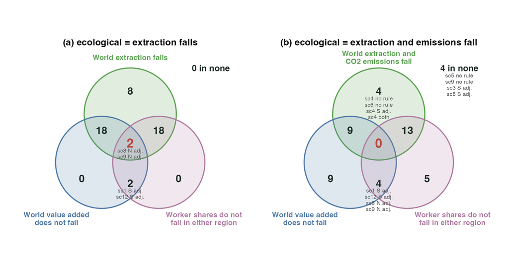

## Family highlights

**In the paper.** Figure 10 of the paper since 2026-11-28 (Results, Size, leverage and the intervention families), replacing Table 2 (the five Ward families): one row per family, one column per dimension and a Policy column. In each dimension, the response on which the family stands out most (largest ratio of its mean |response| to the mean over all 48 runs), its mean over the family's runs, a strength badge (|mean| in sd over the 48 runs) and the family's rank of 5; badge green = improves, red = worsens, grey = no direction (the worker-capitalist income gap widens when workers gain, both regions being above parity on the baseline). Policy: world value added against no rule when the surplus or the deficit region adjusts, regime changes under the three rules, the regime under South money. Source: R/scenarios/highlights_48.R -> family_axis_highlights_48.csv; R/figures/plot_family_highlights_48.R.

48 runs: the North intervenes (sc1-sc12, a 20% substitution from t = 70), North/South, OPENFIX-fiat with the North's bills as the reserve, under no rule and three fiscal rules. Responses are means over t = 79-100 against each run's own baseline (analysis tag 20261121_ce79).

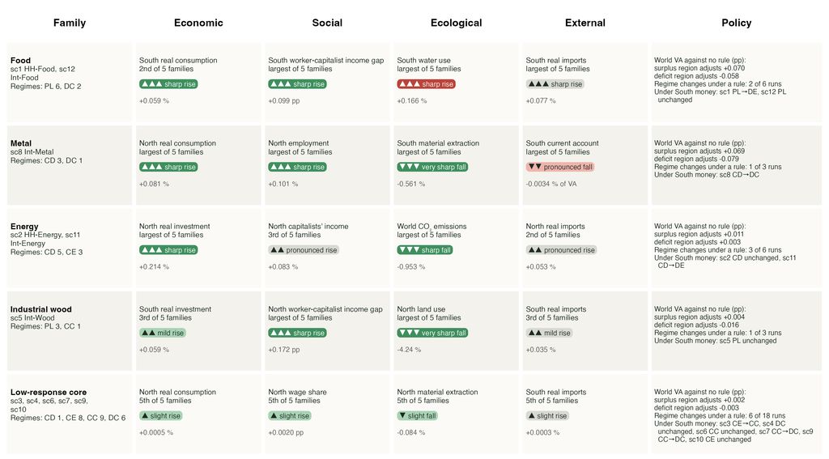

## Regime grid

**In the paper.** Figure 8 of the paper since 2026-11-28 (Results, Direction): the cross-border regime of each intervention under the five arrangements (no rule under North money and under South money; South, North, both adjust), rows grouped by Ward family. Read from runs180.csv (regime column; contained expansion distinguished since 2026-11-26, so it differs from the older regime table in sc3, sc9, sc10 and sc11). Source: R/figures/plot_family_highlights_48.R.

48 runs: the North intervenes (sc1-sc12, a 20% substitution from t = 70), North/South, OPENFIX-fiat with the North's bills as the reserve, under no rule and three fiscal rules. Responses are means over t = 79-100 against each run's own baseline (analysis tag 20261121_ce79).

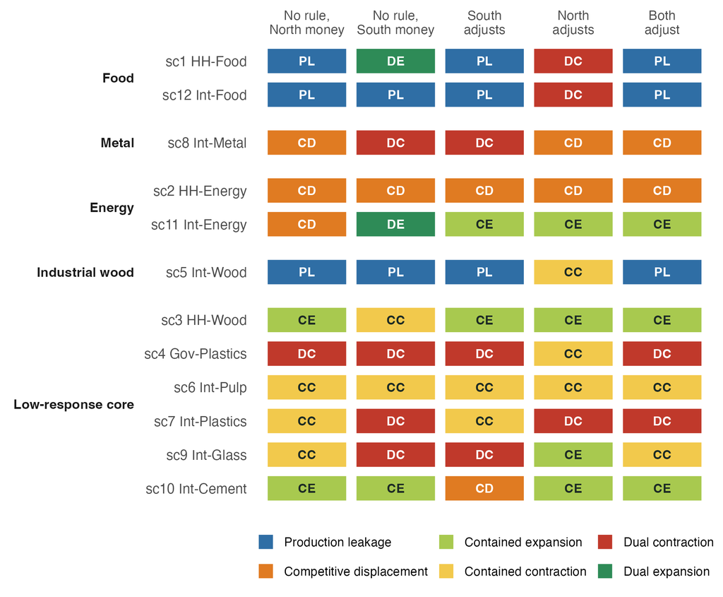

## PCA

**In the paper.** Figure 18 of the paper, in Appendix D1 since 2026-11-28 (moved from the Results; redrawn 2026-11-26): the first two principal components of the 48 runs in the Ward tree's response space. A: the 12 interventions with no fiscal rule, North money, labelled sc#, channel-sector (regimes shaded twice: opaque over the 12 no-adjustment runs, light over all 60 runs incl. the 12 South-money runs, so dual expansion (sc1 and sc11 under South money only) shows; dashed = the five families as hulls; both panels draw the same polygons on the same axes). B: the 36 fiscal-rule runs and the 12 no-rule runs under South money (projected onto A's axes), each joined to its intervention's position in A. Source: R/figures/plot_anova_pca_48.R.

48 runs: the North intervenes (sc1-sc12, a 20% substitution from t = 70), North/South, OPENFIX-fiat with the North's bills as the reserve, under no rule and three fiscal rules. Responses are means over t = 79-100 against each run's own baseline (analysis tag 20261121_ce79).

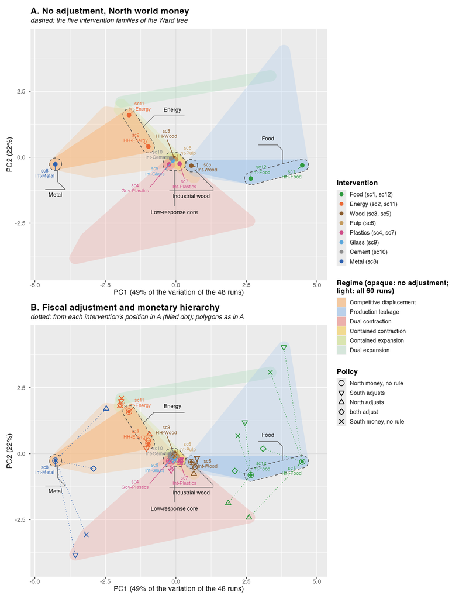

## Families

**In the paper.** Figure 17 of the paper, in Appendix D1 since 2026-11-28 (moved from the Results): five intervention families read from the nesting of the tree since 2026-11-25 (food, metal, energy, industrial wood, low-response core; wood leaves the core at k = 9). The 96-run annotated Ward figure of the earlier revision adapted to the 48 runs: the paper's tree, each leaf with its scenario and regime, channel, sector, the adjuster (none, South, North, both) and its adjustment (expansion when the adjuster is the surplus region, contraction when it is the deficit region; exp. + contr. when both adjust). The strength column was dropped. Groups: the k = 4 cut, the largest at which no intervention is split (k = 5 splits sc1 HH-Food, k = 7 sc8 Int-Metal, and sc5 Int-Wood separates only at k = 9). Source: R/figures/plot_ward_groups_48.R.

48 runs: the North intervenes (sc1-sc12, a 20% substitution from t = 70), North/South, OPENFIX-fiat with the North's bills as the reserve, under no rule and three fiscal rules. Responses are means over t = 79-100 against each run's own baseline (analysis tag 20261121_ce79).

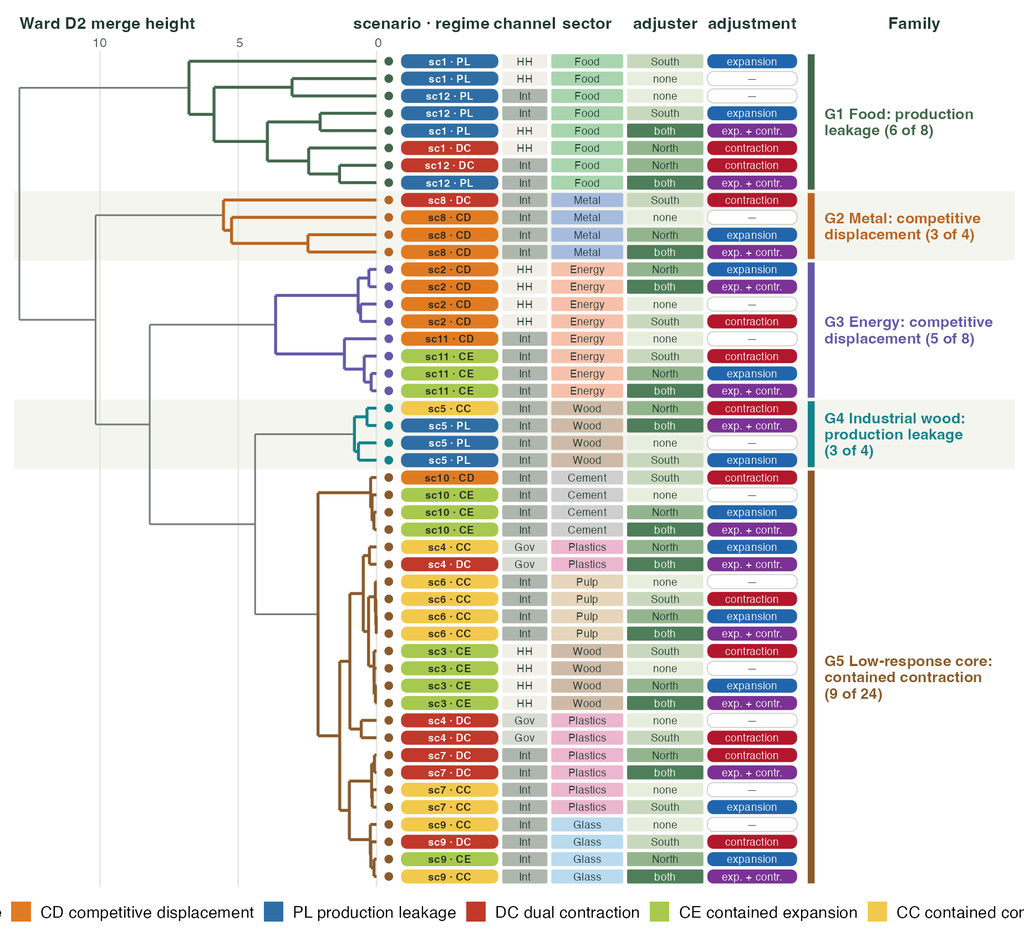

## Regime counts

**Not in the paper.** Moved from Candidates to Not in the Paper 2026-11-27 (author). The 48-run regime counts of the Scenario Regimes page: by policy, by who adjusts (surplus or deficit region), who bears the adjustment, and by intervention. Not in the paper; the Ward figure carries the regimes there. Source: tools/site/generate_results_180.R.

48 runs: the North intervenes (sc1-sc12, a 20% substitution from t = 70), North/South, OPENFIX-fiat with the North's bills as the reserve, under no rule and three fiscal rules. Responses are means over t = 79-100 against each run's own baseline (analysis tag 20261121_ce79).

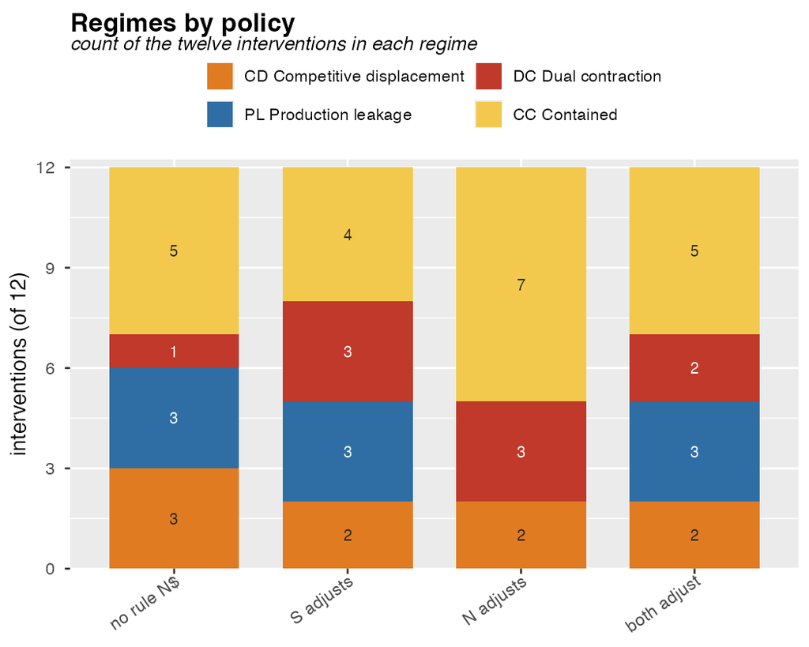

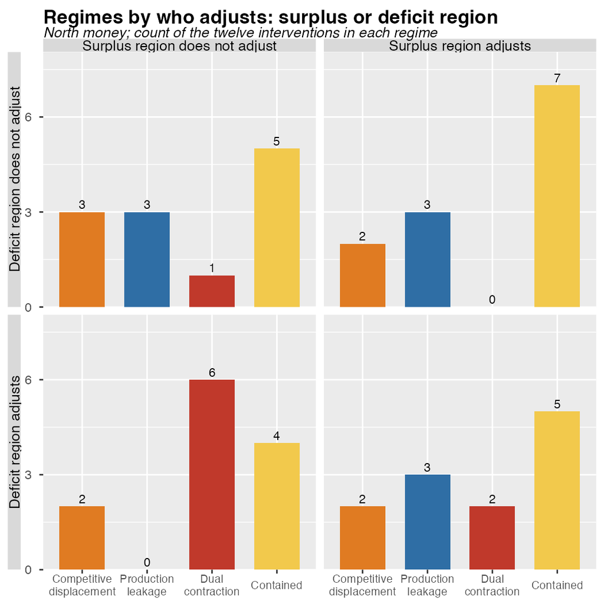

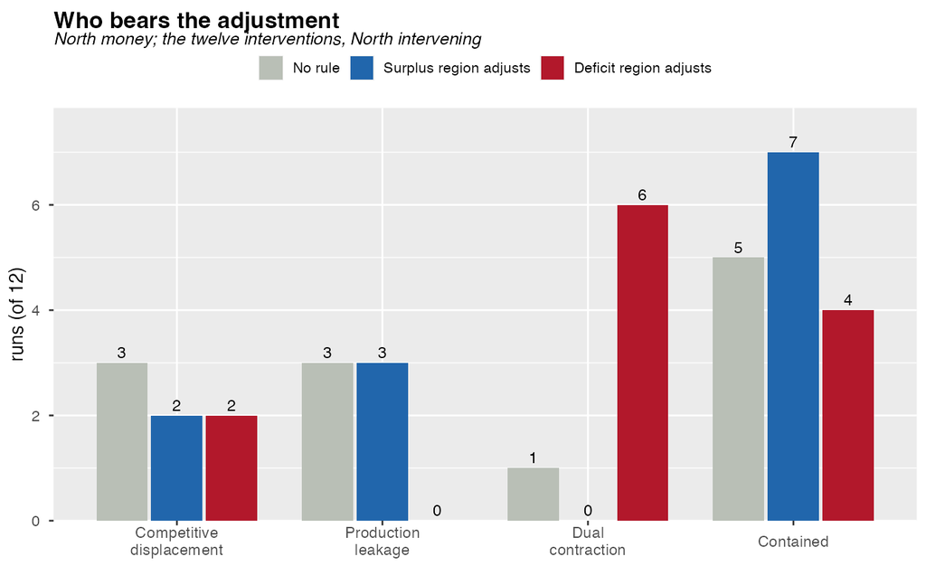

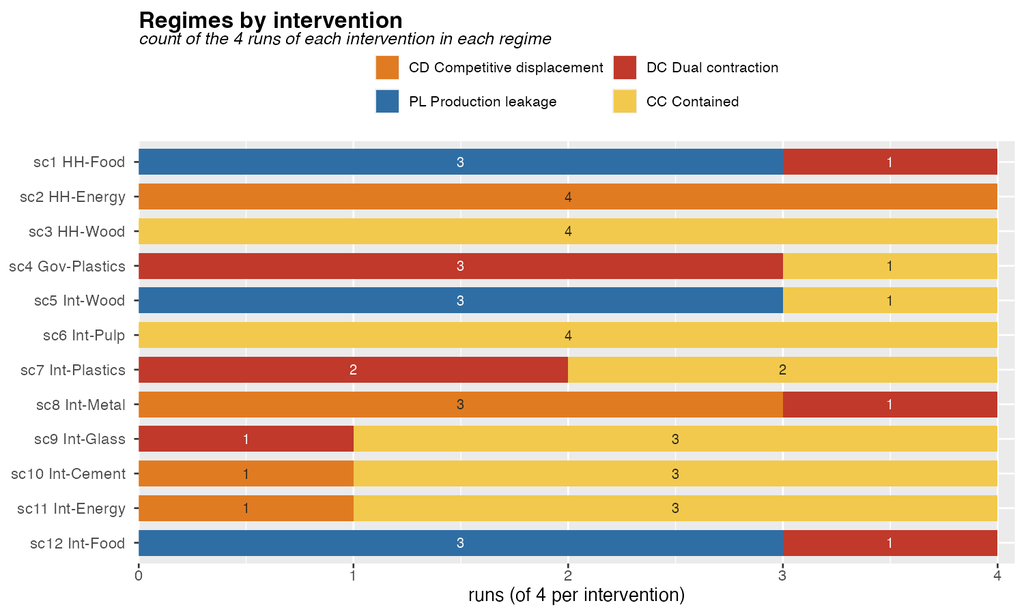

## Effects, all rules

48 runs: the North intervenes (sc1-sc12, a 20% substitution from t = 70), North/South, OPENFIX-fiat with the North's bills as the reserve, under no rule and three fiscal rules. Responses are means over t = 79-100 against each run's own baseline (analysis tag 20261121_ce79).

### North

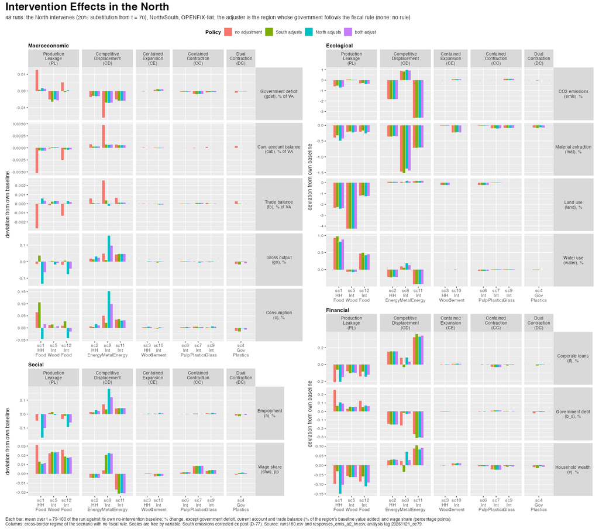

### South

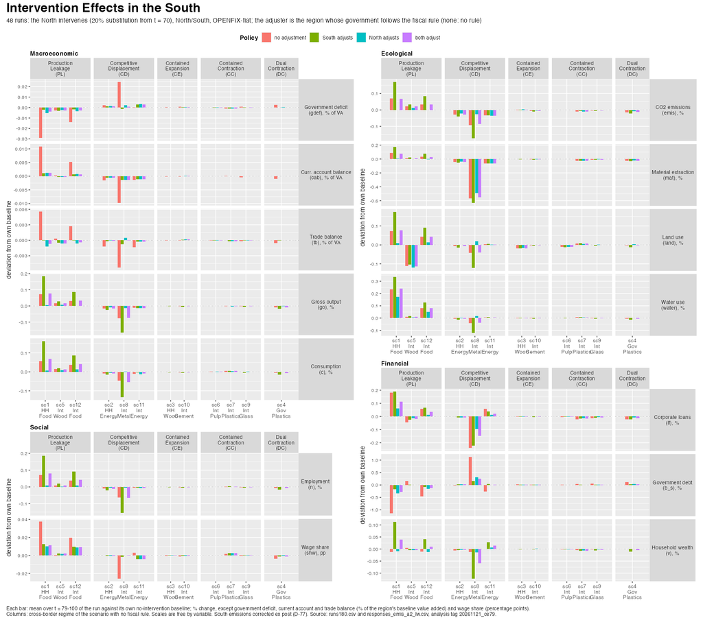